# Homework 4

### Author: Mateusz Sieniawski

I was working on house pricing dataset (https://github.com/pbiecek/InterpretableMachineLearning2020/issues/6).

## (4)

First I trained a XGBoost model. I found two observation such that their CP profiles for variable "longitude" differ.

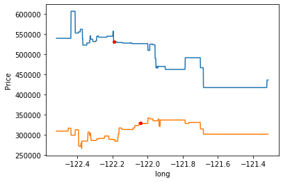

For the first observation (blue) we that moving to the right makes the price lower, wheras moving to the left makes the price larger.

For the second observation (orange) changing longitude a lot (either to the left or right) makes the price decrease a little bit.

I was wondering why would this happen, so I looked at the map:

[figure not shown]

Now everthing makes sense! Moving the first observation (at the top) to the left makes it closer to the city center thus increasing the price. Moving it to the right makes it farther from the most developed part of the city thus making the price decrease.

## (5)

The second model I trained was LightGBM. Generally profiles of these two (XGBoost and LightGBM) looked very similar. In particular the profiles for the two most important features ('longitude' and 'grade') looked almost the same for most observations. After a long search I found an observation, that it's CP profiles differ:

```
XGBoost CP profile:
```

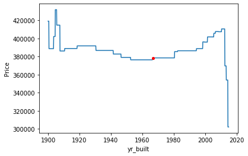

```
LightGBM CP profile:
```

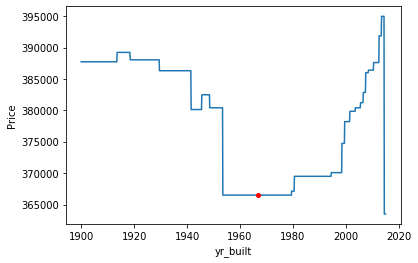

Both models have tendency to lower the price if the building was built between 1950 and 2000:

```
XGBoost:
```

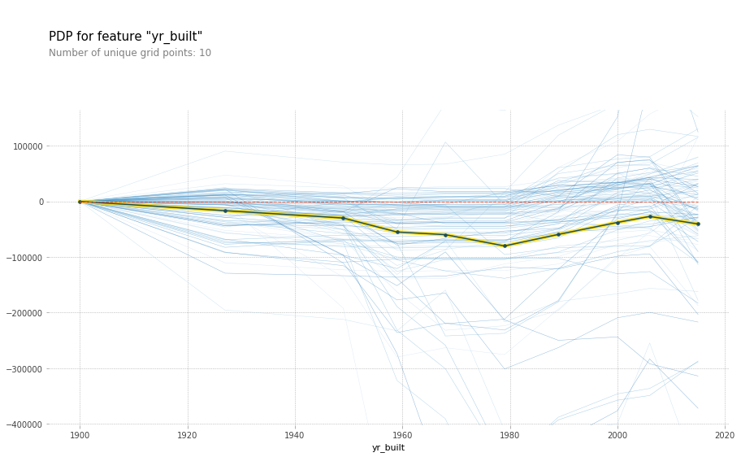

```
LightGBM:
```

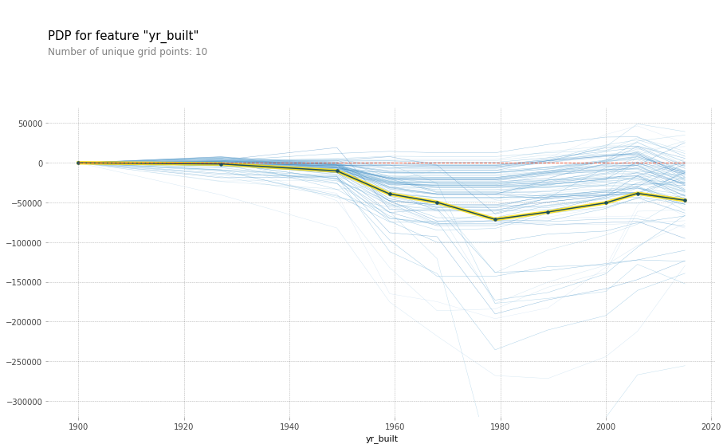

It actually makes sense. The new buildings (built after 2000) might have their price higher due to the "freshness" of the building. A new building is more attractive to the consumer. It really makes a difference if a building is 5 or 10 years old. But it doesn't makes much difference if a building is 40 or 45 years old.

On the other hand, the old building might also have higher prices as many people value "antique" building and are wiling to pay much to live in them.